# Machine Learning in Python - Project 2

Due Wednesday, April 15th by 5 pm.

## 1. Setup

### 1.1 Libraries

```python
# Add any additional libraries or submodules below

# Display plots inline
%matplotlib inline

# Data libraries
import pandas as pd
import numpy as np

# Plotting libraries
import matplotlib.pyplot as plt
import seaborn as sns

# Plotting defaults
plt.rcParams['figure.figsize'] = (8,5)
plt.rcParams['figure.dpi'] = 80

# sklearn modules
import sklearn
from sklearn.ensemble import RandomForestClassifier
from sklearn.feature_selection import f_classif
from sklearn.metrics import accuracy_score, f1_score, log_loss
from sklearn.preprocessing import StandardScaler
from sklearn.decomposition import KernelPCA
from sklearn.utils import safe_mask
from sklearn.model_selection import GridSearchCV
```

### 1.2 Data

```python
wine_train = pd.read_csv("wine_qual_train.csv")
wine_test  = pd.read_csv("wine_qual_test.csv")
```

## 2. Exploratory Data Analysis and Preprocessing

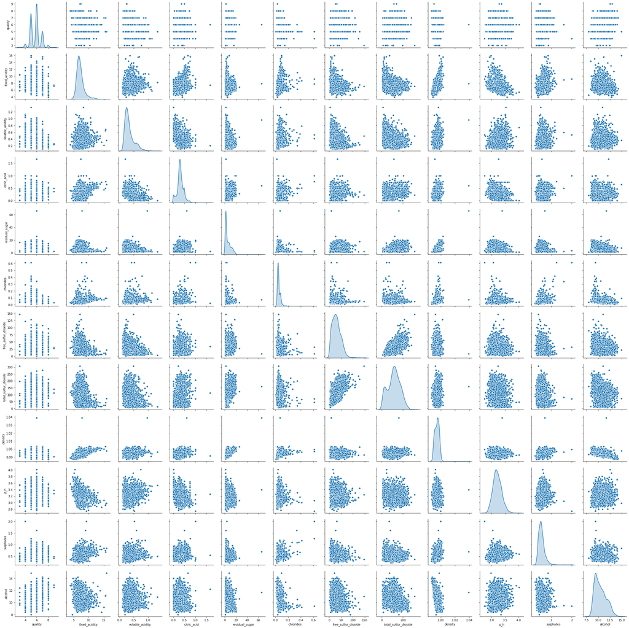

```python
#pairwise plot
sns.pairplot(wine_train, diag_kind='kde')
```

```python
def plot_logscale(X, field):
    '''
    This function will plot the distribution of original data and log data.
    '''

    fig, ax = plt.subplots(1, 2, figsize = [17, 4])
    plt.subplot(121)
    sns.kdeplot(X[field], label = field)
    plt.title('Kdeplot of {}'.format(field))
    plt.xlabel(field)

    plt.subplot(122)
    sns.kdeplot(np.log(X[field]), label = 'log {}'.format(field))
    plt.title('Kdeplot of Log {}'.format(field))
    plt.xlabel('Log {}'.format(field))
```

```python
def convert_label(data):
    '''
    This function is used to convert the numeric label into {1,2,3,4} which means
    level Poor, Average, Good, Excellent
    '''

    data['quality_level'] = data.quality
    data.loc[data.quality_level <= 4, 'quality'] = 1
    data.loc[data.quality_level == 5, 'quality'] = 2
    data.loc[data.quality_level == 6, 'quality'] = 3
    data.loc[data.quality_level >= 7, 'quality'] = 4
    data_new = data.drop('quality_level', axis=1)

    return data_new
```

```python
def remove_out(train_X,train_y):
    '''
    This function is used to remove out the outliers by union all the outliers from each feature. The
    distance range is Q1 - 5IQR to Q3 + 5IQR
    '''
    numeric_train_X = train_X.drop(['wine_red', 'wine_white'], axis = 1)

    outliers = set()
    # For each feature find the data points with extreme high or low values
    for feature in numeric_train_X.keys():
        Q1 = np.percentile(numeric_train_X[feature], q=25)
        Q3 = np.percentile(numeric_train_X[feature], q=75)
        interquartile_range = Q3 - Q1
        step = 5 * interquartile_range
        outlier_index = numeric_train_X[~((numeric_train_X[feature] >= Q1 - step) & (numeric_train_X[feature] <= Q3 + step))].index
        outliers = outliers.union(outlier_index)

    outliers = np.array(list(outliers))

    # Remove the outliers
    train_X_out = train_X.drop(train_X.index[outliers]).reset_index(drop = True)
    train_y_out = train_y.drop(train_y.index[outliers]).reset_index(drop = True)

    return train_X_out,train_y_out
```

```python
def process(train, test, is_out=True):
    '''
    This function is used to process the input data:
        1. Dummy categorical data
        2. Convert quality to numerical category
        3. Log scale the fixed acidity of training data and test data
        4. Outlier detection by union all the outliers from each feature. The
        distance range is Q1 - 5IQR to Q3 + 5IQR
        5. Standardize the training data and test data with 0 mean and 1 variance
    '''

    #----------------------1------------------------------------
    ## One-hot encoding
    data_train = pd.get_dummies(train)
    data_test = pd.get_dummies(test)
    #----------------------2------------------------------------
    #Convert numeirc labels to categories
    wine_train_convert = convert_label(data_train)
    wine_test_convert = convert_label(data_test)

    #split the train data, label and test data, label
    train_data = wine_train_convert.drop('quality', axis=1)
    train_label = wine_train_convert.quality
    test_data = wine_test_convert.drop('quality', axis=1)
    test_label = wine_test_convert.quality
    #----------------------3------------------------------------
    #log scale training data
    train_data.fixed_acidity = np.log(train_data.fixed_acidity)
    test_data.fixed_acidity = np.log(test_data.fixed_acidity)
    #----------------------4------------------------------------
    if is_out:
        #get the outlier index
        train_data_good, train_label_good = remove_out(train_data, train_label)

    #----------------------5------------------------------------
    scaler     = StandardScaler().fit(train_data_good)
    X_train_sc = scaler.transform(train_data_good)
    X_test_sc  = scaler.transform(test_data)

    return X_train_sc, train_label_good, X_test_sc, test_label
```

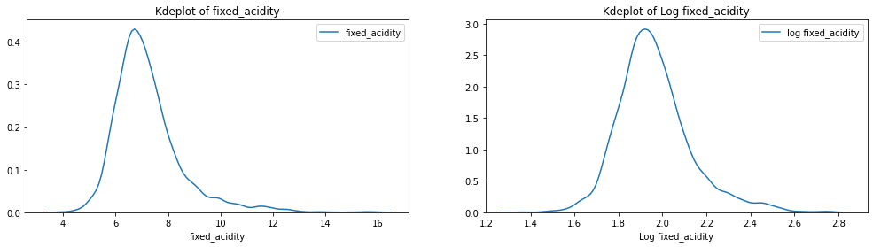

```python
plot_logscale(wine_train, 'fixed_acidity')
```

I have used PCA, KernelPCA and t-sne dimension reduction method and plot the 2 dimensional figure in order to see how well the wine is separated. The results are surprising to me. The different taste wine points all get together. There is no clear cluster and hard to discriminate them. The dimension reduction method details can be seen in suplementary report. This may be the reason that SVC, MR and other classifiers are not good describe in the model fitting part.

In the preprocess stage, I perform five transformations to the original data in `process` function.

1. Dummy categorical data wine.
2. Design a function `convert_label` which can convert numerical quality into categorical quality. Here I use numerical category to represent 4 qualities because in empirical experiment, it performs a little better.
3. From pair plot at beginning, we can find there are several features are right skewed. After comparing the impact of trying log scale to different features of training data, I find only the **fixed acidity** have the positive impact to the model performance. So I only perform log scale to the **fixed acidity** and the kdeplot can be seen above. We can find after log scale, the distribution of **fixed acidity** becomes symmetric and it is easier to do prediction.
4. Remove out the outliers by union all the outliers from each feature. The outlier is outside the distance range of Q1 - 5IQR to Q3 + 5IQR.
5. Use `StandardScaler` to standardize the training data and test data to 0 mean and 1 variance.

```python
X_train, y_train, X_test, y_test = process(wine_train, wine_test)
```

## 3. Model Fitting and Tuning

I have tried multinomial logistic regression (MR), K-nearest-neighbor classifier (KNN), support vector machine classifier with rbf, poly and linear kernel (SVC), randomforest classifier (RF), decision tree and other 4 classifiers which can be seen in supplementary report. The individual decision trees have high variance and easy to overfit, so I reject it. The performance of MR, KNN and SVC with poly kernel are not good, among accuracy, weighted average f1-score (WA F1-score) and Log-loss. Although the log-loss of SVC with rbf and linear kernel is smaller, the accuracy and WA F1 score are much worse than RF, so I reject them. The comparison results can be seen below which shows the RF has the best performance. So I choose RF as my final model with best accuracy and WA F1 score, and proper log-loss.

| MODELS | Accuracy | WA F1 Score | Log-loss |
| --- | --- | --- | --- |
| Logistic regression (one_vs_rest) | 0.21 | 0.07 | 5.1 |
| Logistic regression (multinomial) | 0.21 | 0.08 | 14.7 |
| support vector machine (linear) | 0.43 | 0.26 | 1.5 |
| support vector machine (poly) | 0.04 | 0.003 | 11.1 |
| support vector machine (rbf) | 0.43 | 0.15 | 1.4 |
| DecisionTreeClassifier | 0.52 | 0.51 | 14.8 |
| **RandomForestClassifier** | **0.67** | **0.65** | **3.5** |
| KNeighborsClass | 0.44 | 0.37 | 7.86 |

The random forest classifier I used is from sklearn `RandomForestClassifier` module and it is easy to use and interpret. *RandomForest* is an algorithm which combines diverse decision trees from randomly selected subset of training set (*bootstrap sampling*). The final class of the test object is decided by aggregating of the votes from different decision trees.  
Here, I only tune the parameter `n_estimators` (i.e. the number of decision trees in the forest) in the `RandomForestClassifier`. Although the larger `n_estimator`, the better performance. it will also cost more time and after a critical number, the results will not get significantly improvement. So in the gridsearch part, I only search the number of trees from 150 to 170. It reduce the time cost and can give a well result. The other parameters (e.g. `max_features`, the random subsets of features to consider when splitting a node) are empirical good default and I don't need to change them.

```python
def model_fit(clf, X_train, X_test, y_train, y_test):
    '''
    Print the accuracy, weighted average f1-score, confusion matrix and classification report
    '''

    clf.fit(X_train, y_train)
    y_pred = clf.predict(X_test)
    dict = {1: 'Poor', 2: 'Average', 3: 'Good', 4: 'Excellent'}
    y_pred = pd.Series(y_pred).replace(dict)
    y_true = y_test.replace(dict)
    print('Accuracy: ', accuracy_score(y_true, y_pred), '\n',
          'F1-score: ', f1_score(y_true, y_pred, average='weighted'), '\n',
          'Log-loss', log_loss(y_true, clf.predict_proba(X_test)))
    confusion_mat = sklearn.metrics.confusion_matrix(y_true, y_pred)
    df_cm = pd.DataFrame(confusion_mat)
    df_cm.index = ['Average', 'Excellent', 'Good', 'Poor']
    df_cm.columns = ['Average', 'Excellent', 'Good', 'Poor']
    ax, fig = plt.subplots(figsize=(6,4))
    sns.set(font_scale=1.4)
    sns.heatmap(df_cm, annot=True, annot_kws={'size': 16}, fmt='g')
    plt.title('Confusion Matrix')
    print('classification report: \n', sklearn.metrics.classification_report(y_true, y_pred))
```

Then I use `gridsearchcv` to find the best parameter `n_estimators`, the number of folds is set to 5, the scoring method is weighted average f1-score.

```python
def best_param(X_train, y_train, X_test, y_test):
    '''
    This function used gridsearchcv to find the best parameter of n_estimators and fit the model
    '''

    #parameter tuning with more alphas and less number gammas
    clf = GridSearchCV(RandomForestClassifier(random_state=1, n_jobs = -1),
                 param_grid={"n_estimators": np.linspace(150, 170, num=20, dtype=int)},
                 scoring = 'f1_weighted', cv=5)

    #test model
    model_fit(clf, X_train, X_test, y_train, y_test)

    return clf
```

## 4. Discussion

My final model is RF model. This model will use bootstrap method sampling the training data and create a set of decision trees. I use the best number of trees in the forest and give the good classification results. The data used for this model has both nemeric data and categorical data (only zero and one). I also use log scale of `fixed acidity` because they are right skewed and using log scale will make prediction better. below is my model performance for test data.

```
Accuracy:  0.666
 F1-score:  0.648423656394422
 Log-loss 3.4619240277954386
classification report:
               precision    recall  f1-score   support

     Average       0.69      0.74      0.71       325
   Excellent       0.79      0.42      0.55       202
        Good       0.62      0.79      0.69       429
        Poor       1.00      0.09      0.17        44

    accuracy                           0.67      1000
   macro avg       0.78      0.51      0.53      1000
weighted avg       0.70      0.67      0.65      1000
```

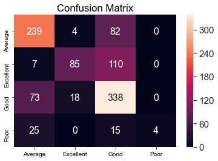

```python
model = best_param(X_train, y_train, X_test, y_test)
```

This model has the accuracy of 0.666, the F1-score of 0.648 and the Log-loss of 3.46 which are much better than the baseline model: classify the wine taste by the most frequent label or random label. The baseline model comparison can be found in supplementary report. From the final column of confusion matrix, we can find there are no average, good and excellent taste wine are misclassified to poor. Also, we can find from first, second and third rows from confusion matrix, most of each taste wine are only misclassified to their closed taste type (e.g. 82 of the average taste wine are misclassified to good and only 4 are misclassified to excellent). So my model is both accurate and useful.

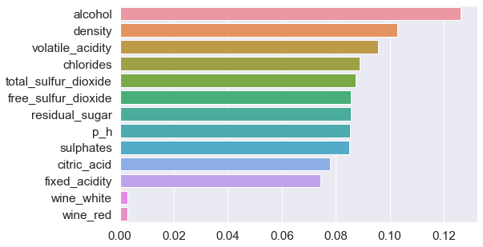

```python
column = pd.get_dummies(wine_train).drop('quality', axis = 1).columns
clf_improtance = model.best_estimator_.feature_importances_
##Printing out the head of the importances for all features.
importance = pd.Series(np.round(clf_improtance, 4),
                          index = column)
importance = importance.sort_values(ascending=False)
plt.figure(figsize=(8,5))
sns.barplot(x = importance, y = importance.index)
```

## 5. Model Validation

The total accuracy, weighted average f1-score and Log-loss are 0.67, 0.65 and 3.5. which are very good compare to the baseline model. When a new wine comes, this model may give a correct prediction of probability 0.70 (i.e. the weighted average precision). This model will take all the information provided and classfy the 4 tastes wine.

```python
wine_holdout = pd.read_csv("wine_qual_holdout.csv")

#Preprocess the holdout data
X_train, y_train, X_holdout, y_holdout = process(wine_train, wine_holdout)
```

[output not shown]

[figure not shown]

```python
#Thest the holdout data
best_model = best_param(X_train, y_train, X_holdout, y_holdout)
```